# Practical on mechanistic recruitment models

Bitetto Isabella - COISPA

2024-11-08

## Introduction

To test the significance of environmental variables on recruitment process, first we need to select meaningful covariates. The environmental time series used in this tutorial have been derived from Copernicus (https://www.copernicus.eu/en, reanalysis approach on Bernhard presentation)

The variables here considered are:

- the sea surface temperature (SST),
- bottom temperature (botT),
- salinity (so),
- bottom salinity (botso)
- net primary production value (nppv).

The environmental data are considered on a depth range based on the distribution of each species in the study area:

- European hake: 50-500 m;
- red mullet: 0-200 m;
- deep-water rose shrimp:50-500 m;
- red shrimps: 200-800 m

and grouped in GSAs based on the stock unit considered. Monthly values of the environmental variables were averaged yearly for each depth range considered.

The environmental data related to the past and present years (hind cast) span from 1987 to 2021 while the projections cover the years 2006-2099.

Also for the projections, the environmental data were obtained from 3D monthly POLCOMS-ERSEM dataset with a resolution of 0.1° (approximately 10 km) for two RCP (Representative Concentration Pathways) climate scenarios: + a moderate one, the RCP4.5 + the RCP8.5 (no climate protection) as the highest baseline emissions scenario in which emissions continue to rise throughout the twenty-first century (i.e. until 2099).

## Required packages to run this tutorial

In order to execute the code in this tutorial you should have the following packages installed:

CRAN: modelr, nlstools, MuMIn, rlist, formula.tools, corrplot

```r
#install.packages(c("modelr","nlstools","MuMIn","rlist","formula.tools","corrplot"),repos="https://cloud.r-project.org")

library(modelr)
library(nlstools)
library(MuMIn)
library(rlist)
library(formula.tools)
library(corrplot)
```

## Loading the datasets

```r
load("Recruitment_tutorial_data.Rdata")

head(data)
```

```
##    Year Rec..thousands. Spawning.Stock.Biomass   Stock Comments
## 78 2004           76443                   1426 Hake 19
## 79 2005           64670                   1164 Hake 19
## 80 2006           61241                   1256 Hake 19
## 81 2007           50532                   1336 Hake 19
## 82 2008           49805                   1338 Hake 19
## 83 2009           48535                   1301 Hake 19
```

```r
load("env_hindcast.Rdata")

head(env_hindcast)
```

```
##    YEAR      sst     botT       so    botso     nppv
## 11 2004 19.72697 14.48991 38.32453 38.83344 7.225076
## 12 2005 19.55681 14.37562 38.41104 38.83068 6.752740
## 13 2006 19.85257 14.09209 38.38418 38.76149 6.996086
## 14 2007 19.87155 14.29328 38.21125 38.75390 6.735268
## 15 2008 19.90038 14.19708 38.27818 38.74645 6.928412
## 16 2009 19.77362 14.09316 38.17182 38.69855 7.235263
```

```r
case="HKE19"
```

# Exploring correlations among covariates

Correlation plots provide a quick, intuitive way to assess relationships at a glance.Our objective in this case is to avoid including correlated variables in the model fitting process to minimize redundancy and reduce the risk of spurious relationships. For European hake in the Western Ionian Sea, we observe that sea surface temperature (SST) is highly correlated with bottom temperature, and bottom salinity is correlated with all variables except nppv. Therefore, we will explore models that include one of the correlated variables at a time to ensure a more robust analysis.

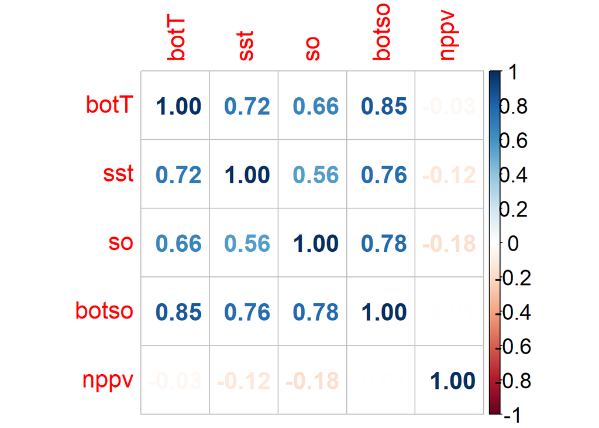

```r
data= data[data$Year %in% unique(env_hindcast$YEAR),]
y=data[,c(1)]
R=as.numeric(data[,c(2)])
S=as.numeric(data[,c(3)])



botT<-env_hindcast$botT
sst <-env_hindcast$sst
so  <-env_hindcast$so
botso<-env_hindcast$botso
nppv<-env_hindcast$nppv

varr=cbind(botT,sst,so,botso,nppv)[-c(1:5),]
M = cor(varr)
corrplot(M, method = 'number',type="full",number.cex=1.7,tl.cex=1.7,cl.cex=1.5,na.rm=TRUE)
```

# Fitting Environmentally Mediated Stock-Recruitment models

## Beverton and Holt

In this part of the code the years where the environmental information is available are selected. Then, we fit the models starting from seed values a and b of the Beverton and Holt SRR. Initial values can be derived from previous estimates, stock assessment or by literature.

We first fit the classical model without environmental variabes that we will define as naive model.

```r
ain=86.69208
bin=5.99E-04

data_case<-data.frame(cbind(data,botT,sst,so,botso,nppv))
colnames(data_case)[1:3]<-c("year","R","S")
#data_case<-cbind(data_case,env_hindcast$botT,env_hindcast$sst,env_hindcast$so,env_hindcast$botso,env_hindcast$nppv)

N=length(y)
table_res<-c()

R=as.numeric(data_case$R)
S=as.numeric(data_case$S)
y=as.numeric(data_case$year)



mod<-nls(R~ a*S/(1+b*S), start=list(a=ain,b=bin) )
err<-residuals(mod)
N_nona<-N-sum(length(which(is.na(err))))
SSE=sum(err^2,na.rm=T)
ME=sum(abs(err),na.rm=T)/N_nona
MSE=SSE/N_nona+ME^2

table_res<-rbind(table_res, c(
  paste("BH"),
  as.character(formula(mod)) ,
  coeffs(mod),"","", "",AIC(mod) , SSE, ME, MSE) )

modR<-list(classic=mod)
```

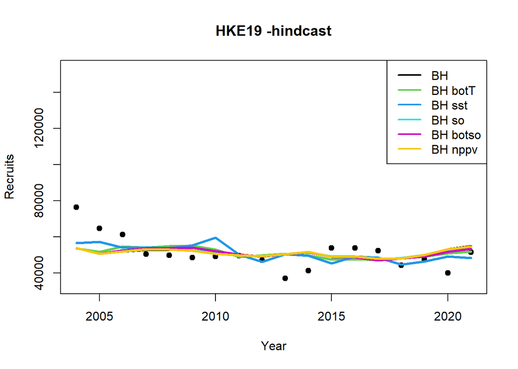

```r
ain<-coeffs(mod)[1]
bin<-coeffs(mod)[2]
cin<-0.1
din<-0.1
fin<-0.1

data_case$S<-as.numeric(data_case$S)
data_case$R<-as.numeric(data_case$R)

plot(y,R,lwd=1,pch=19,xlab="Year",ylab="Recruits",ylim=c(min(R)*0.9,max(R)*2))
lines(y,predict(modR[[1]]),lwd=3,col="black")
title(paste(case, "-hindcast"))
legend_names<-"BH"
legend_color<-"black"
legend_lty<-1

#botT
mod<-nls(R~a*S/(1+b*S)*exp(-c*botT), start=list(a=ain,b=bin,c=cin),data=data_case )
err<-residuals(mod)
N_nona<-N-sum(length(which(is.na(err))))
SSE=sum(err^2,na.rm=T)
ME=sum(abs(err),na.rm=T)/N_nona
MSE=SSE/N_nona+ME^2
table_res<-rbind(table_res, c(
  paste("BH botT"),
  as.character(formula(mod)),coeffs(mod),"","", AIC(mod) , SSE, ME, MSE) )
modR<-list.append(modR, botT=mod)
lines(y,predict(mod),lwd=3,col=3)
legend_color<-c(legend_color,3)
legend_names<-c(legend_names, "BH botT")
legend_lty<-c(legend_lty,1)


#sst
mod<-nls(R~ a*S/(1+b*S)*exp(-c*sst), start=list(a=ain,b=bin,c=cin),data=data_case )
err<-residuals(mod)
N_nona<-N-sum(length(which(is.na(err))))
SSE=sum(err^2,na.rm=T)
ME=sum(abs(err),na.rm=T)/N_nona
MSE=SSE/N_nona+ME^2
table_res<-rbind(table_res, c(
  paste("BH sst"),
  as.character(formula(mod)),coeffs(mod),"", "",AIC(mod) , SSE, ME, MSE) )
modR<-list.append(modR, sst=mod)
lines(y,predict(mod),lwd=3,col=4)
legend_color<-c(legend_color,4)
legend_names<-c(legend_names, "BH sst")
legend_lty<-c(legend_lty,1)


# #so
  mod<-nls(R~a*S/(1+b*S)*exp(-c*so), start=list(a=ain,b=bin,c=cin),data=data_case )
  err<-residuals(mod)
  N_nona<-N-sum(length(which(is.na(err))))
  SSE=sum(err^2,na.rm=T)
  ME=sum(abs(err),na.rm=T)/N_nona
  MSE=SSE/N_nona+ME^2
  table_res<-rbind(table_res, c(
    paste("BH so"),
    as.character(formula(mod)),coeffs(mod),"", "",AIC(mod) , SSE, ME, MSE) )
  lines(y,predict(mod),lwd=3,col=5)
  legend_color<-c(legend_color,5)
  legend_names<-c(legend_names, "BH so")
  legend_lty<-c(legend_lty,1)


  # #botso
  mod<-nls(R~a*S/(1+b*S)*exp(-c*botso), start=list(a=ain,b=bin,c=cin),data=data_case )
  err<-residuals(mod)
  N_nona<-N-sum(length(which(is.na(err))))
  SSE=sum(err^2,na.rm=T)
  ME=sum(abs(err),na.rm=T)/N_nona
  MSE=SSE/N_nona+ME^2
  table_res<-rbind(table_res, c(
    paste("BH botso"),
    as.character(formula(mod)),coeffs(mod),"","", AIC(mod) , SSE, ME, MSE) )
  lines(y,predict(mod),lwd=3,col=6)
  legend_color<-c(legend_color,6)
  legend_names<-c(legend_names, "BH botso")
  legend_lty<-c(legend_lty,1)

   #nppv
  mod<-nls(R~ a*S/(1+b*S)*exp(-c*nppv), start=list(a=ain,b=bin,c=cin),data=data_case )
  err<-residuals(mod)
  N_nona<-N-sum(length(which(is.na(err))))
  SSE=sum(err^2,na.rm=T)
  ME=sum(abs(err),na.rm=T)/N_nona
  MSE=SSE/N_nona+ME^2
  table_res<-rbind(table_res, c(
    paste("BH nppv"),
    as.character(formula(mod)),coeffs(mod),"", "",AIC(mod) , SSE, ME, MSE) )
  lines(y,predict(mod),lwd=3,col=7)
  legend_color<-c(legend_color,7)
  legend_names<-c(legend_names, "BH nppv")
  legend_lty<-c(legend_lty,1)


legend("topright",legend=legend_names,col=legend_color,lwd=c(2,2),lty=legend_lty)
```

Now we will explore the models with two covariates.

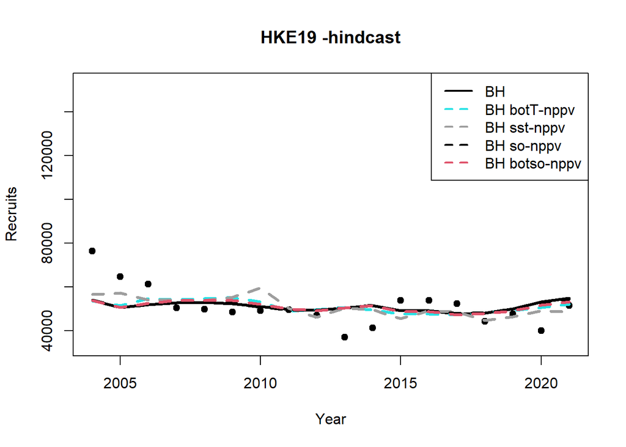

```r
plot(y,R,lwd=1,pch=19,xlab="Year",ylab="Recruits",ylim=c(min(R)*0.9,max(R)*2))
lines(y,predict(modR[[1]]),lwd=3,col="black")
title(paste(case, "-hindcast"))
legend_names<-"BH"
legend_color<-"black"
legend_lty<-1


#botT-nppv
mod<-nls(R~ a*S/(1+b*S)*exp(-c*botT-d*nppv), start=list(a=ain,b=bin,c=cin,d=din),data=data_case )
err<-residuals(mod)
N_nona<-N-sum(length(which(is.na(err))))
SSE=sum(err^2,na.rm=T)
ME=sum(abs(err),na.rm=T)/N_nona
MSE=SSE/N_nona+ME^2
table_res<-rbind(table_res, c(
  paste("BH botT-nppv"),
  as.character(formula(mod)),coeffs(mod),"",AIC(mod) , SSE, ME, MSE) )
modR<-list.append(modR, botTnppv=mod)
lines(y,predict(mod),lwd=3,col=5,lty=2)
legend_color<-c(legend_color,5)
legend_names<-c(legend_names, "BH botT-nppv")
legend_lty<-c(legend_lty,2)



#sst-nppv
mod<-nls(R~ a*S/(1+b*S)*exp(-c*sst-d*nppv), start=list(a=ain,b=bin,c=cin,d=din),data=data_case )
err<-residuals(mod)
N_nona<-N-sum(length(which(is.na(err))))
SSE=sum(err^2,na.rm=T)
ME=sum(abs(err),na.rm=T)/N_nona
MSE=SSE/N_nona+ME^2
table_res<-rbind(table_res, c(
  paste("BH sst-nppv"),
  as.character(formula(mod)),coeffs(mod),"", AIC(mod) , SSE, ME, MSE) )
modR<-list.append(modR, sstnppv=mod)
lines(y,predict(mod),lwd=3,col=8,lty=2)
legend_color<-c(legend_color,8)
legend_names<-c(legend_names, "BH sst-nppv")
legend_lty<-c(legend_lty,2)


# # #so-nppv
  mod<-nls(R~a*S/(1+b*S)*exp(-c*so-d*nppv), start=list(a=ain,b=bin,c=cin,d=din),data=data_case )
  err<-residuals(mod)
  N_nona<-N-sum(length(which(is.na(err))))
  SSE=sum(err^2,na.rm=T)
  ME=sum(abs(err),na.rm=T)/N_nona
  MSE=SSE/N_nona+ME^2
  table_res<-rbind(table_res, c(
    paste("BH so-nppv"),
    as.character(formula(mod)),coeffs(mod),"", AIC(mod) , SSE, ME, MSE) )
  lines(y,predict(mod),lwd=3,col=9,lty=2)
  legend_color<-c(legend_color,9)
  legend_names<-c(legend_names, "BH so-nppv")
  legend_lty<-c(legend_lty,2)


  # #botso-nppv
  mod<-nls(R~ a*S/(1+b*S)*exp(-c*botso-d*nppv), start=list(a=ain,b=bin,c=cin,d=din),data=data_case )
  err<-residuals(mod)
  N_nona<-N-sum(length(which(is.na(err))))
  SSE=sum(err^2,na.rm=T)
  ME=sum(abs(err),na.rm=T)/N_nona
  MSE=SSE/N_nona+ME^2
  table_res<-rbind(table_res, c(
    paste("BH botso-nppv"),
    as.character(formula(mod)),coeffs(mod),"", AIC(mod) , SSE, ME, MSE) )
  lines(y,predict(mod),lwd=3,col=10,lty=2)
  legend_color<-c(legend_color,10)
  legend_names<-c(legend_names, "BH botso-nppv")
  legend_lty<-c(legend_lty,2)

legend("topright",legend=legend_names,col=legend_color,lwd=c(2,2),lty=legend_lty)
```

In this case we do not explore models with three covariates, because of the correlation among them.

# Summary table preparation

A draft summary table is here produced. Looking to the results, the model having the best predictive capability is the one depending only on SST.

```r
table_res<-as.data.frame(table_res)
colnames(table_res)<-c("Model","Formula","a","b","c","d","f","AIC","SSE","MAE","MSE")

table_res$a=as.numeric(table_res$a)
table_res$b=as.numeric(table_res$b)
table_res$c=as.numeric(table_res$c)
table_res$d=as.numeric(table_res$d)
table_res$f=as.numeric(table_res$f)
table_res$AIC=as.numeric(table_res$AIC)
table_res$SSE=as.numeric(table_res$SSE)
table_res$MAE=as.numeric(table_res$MAE)
table_res$MSE=as.numeric(table_res$MSE)

table_res$RMSE=sqrt(table_res$MSE)
table_res$rRMSE=table_res$RMSE/table_res[1,]$RMSE
table_res$rMAE=table_res$MAE/table_res[1,]$MAE

#table_res=rbind(names,table_res)
knitr::kable(table_res,digits=2)
```

| Model | Formula | a | b | c | d | f | AIC | SSE | MAE | MSE | RMSE | rRMSE | rMAE |
| --- | --- | --- | --- | --- | --- | --- | --- | --- | --- | --- | --- | --- | --- |
| BH | R ~ a * S/(1 + b * S) | 133.37 | 0 | NA | NA | NA | 383.89 | 1381182449 | 6661.36 | 121106106 | 11004.82 | 1.00 | 1.00 |
| BH botT | R ~ a * S/(1 + b * S) * exp(-c * botT) | 935.57 | 0 | 0.12 | NA | NA | 385.22 | 1330938798 | 6731.64 | 119256076 | 10920.44 | 0.99 | 1.01 |
| BH sst | R ~ a * S/(1 + b * S) * exp(-c * sst) | 35055.63 | 0 | 0.24 | NA | NA | 382.23 | 1127142847 | 6282.28 | 102086053 | 10103.76 | 0.92 | 0.94 |
| BH so | R ~ a * S/(1 + b * S) * exp(-c * so) | 233.22 | 0 | 0.01 | NA | NA | 385.88 | 1381024140 | 6677.40 | 121311181 | 11014.14 | 1.00 | 1.00 |
| BH botso | R ~ a * S/(1 + b * S) * exp(-c * botso) | 928204.27 | 0 | 0.23 | NA | NA | 385.72 | 1368400945 | 6740.53 | 121457020 | 11020.75 | 1.00 | 1.01 |
| BH nppv | R ~ a * S/(1 + b * S) * exp(-c * nppv) | 132.51 | 0 | 0.01 | NA | NA | 385.88 | 1380715710 | 6651.69 | 120951398 | 10997.79 | 1.00 | 1.00 |
| BH botT-nppv | R ~ a * S/(1 + b * S) * exp(-c * botT - d * nppv) | 965.25 | 0 | 0.13 | -0.01 | NA | 387.22 | 1330791692 | 6735.15 | 119295053 | 10922.23 | 0.99 | 1.01 |
| BH sst-nppv | R ~ a * S/(1 + b * S) * exp(-c * sst - d * nppv) | 36599.72 | 0 | 0.24 | 0.00 | NA | 384.23 | 1127074183 | 6276.71 | 102012316 | 10100.11 | 0.92 | 0.94 |
| BH so-nppv | R ~ a * S/(1 + b * S) * exp(-c * so - d * nppv) | 213.40 | 0 | 0.01 | 0.01 | NA | 387.88 | 1380601562 | 6665.78 | 121132674 | 11006.03 | 1.00 | 1.00 |
| BH botso-nppv | R ~ a * S/(1 + b * S) * exp(-c * botso - d * nppv) | 858106.55 | 0 | 0.23 | 0.01 | NA | 387.72 | 1368289139 | 6735.05 | 121376992 | 11017.12 | 1.00 | 1.01 |

# Conclusions

Note that here only the BevHolt model estimation was reported, but Ricker and hockey stick were also explored in SEAwise.

Using the presented approach it is possible to explore any SRR model just adapting the script. It would be also possible to adapt the scipt to fit EMSRR applying a model error approach (in case a robust and contrasted data set is available).

More complex model performance indicators can be introduced following Marc presentation on model selection.